# Elective Project: Pratical Data Science - Potential Customers Prediction

## 3. EDA on Models Predictions

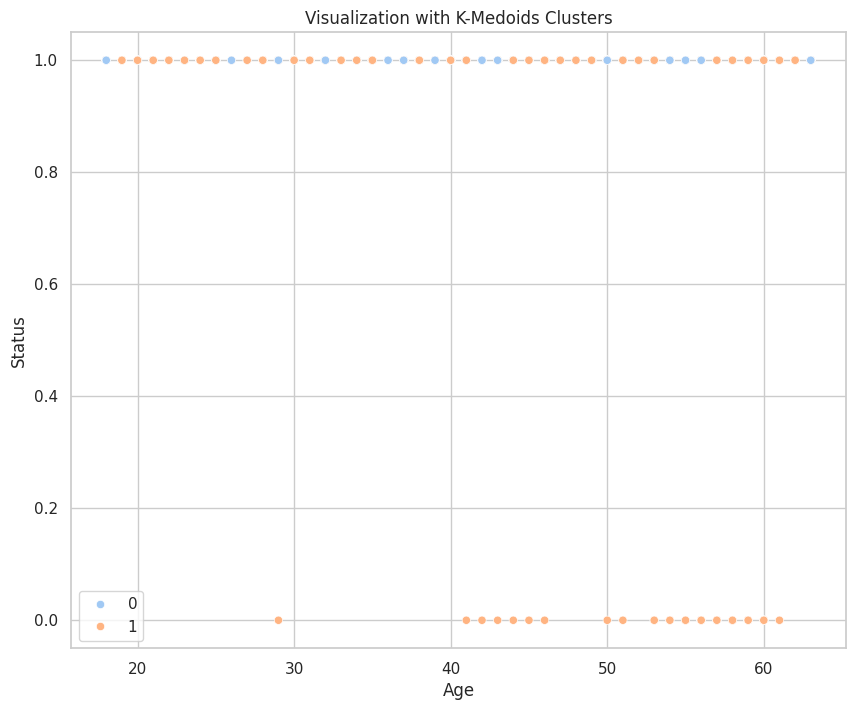

```python
# Specify the number of clusters
num_clusters = 2


# Select numerical columns for clustering
numerical_columns = X_fold_val

# Initialize K-Medoids model
kmedoids = KMedoids(n_clusters=num_clusters, random_state=42)

# Fit K-Medoids model
cluster_assignments = kmedoids.fit_predict(numerical_columns)

# Visualize clustering results
plt.figure(figsize=(10, 8))
sns.scatterplot(x=numerical_columns.iloc[:, 0], y=y_pred_val_binary.ravel(), hue=cluster_assignments, legend='full')

# Set labels and title
plt.xlabel('Age')
plt.ylabel('Status')
plt.title('Visualization with K-Medoids Clusters')

# Show the plot
plt.show()
```

The age profile of converted leads is not linear does not discrimate well.

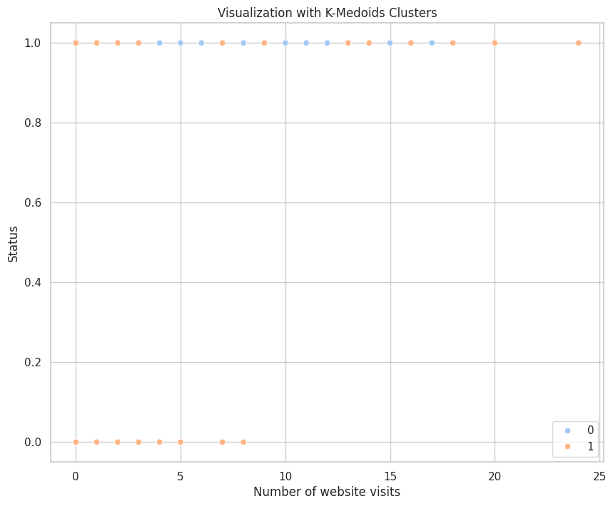

```python
# Specify the number of clusters
num_clusters = 2


# Select numerical columns for clustering
numerical_columns = X_fold_val

# Initialize K-Medoids model
kmedoids = KMedoids(n_clusters=num_clusters, random_state=42)

# Fit K-Medoids model
cluster_assignments = kmedoids.fit_predict(numerical_columns)

# Visualize clustering results
plt.figure(figsize=(10, 8))
sns.scatterplot(x=numerical_columns.iloc[:, 1], y=y_pred_val_binary.ravel(), hue=cluster_assignments, legend='full')

# Set labels and title
plt.xlabel('Number of website visits')
plt.ylabel('Status')
plt.title('Visualization with K-Medoids Clusters')

# Show the plot
plt.show()
```

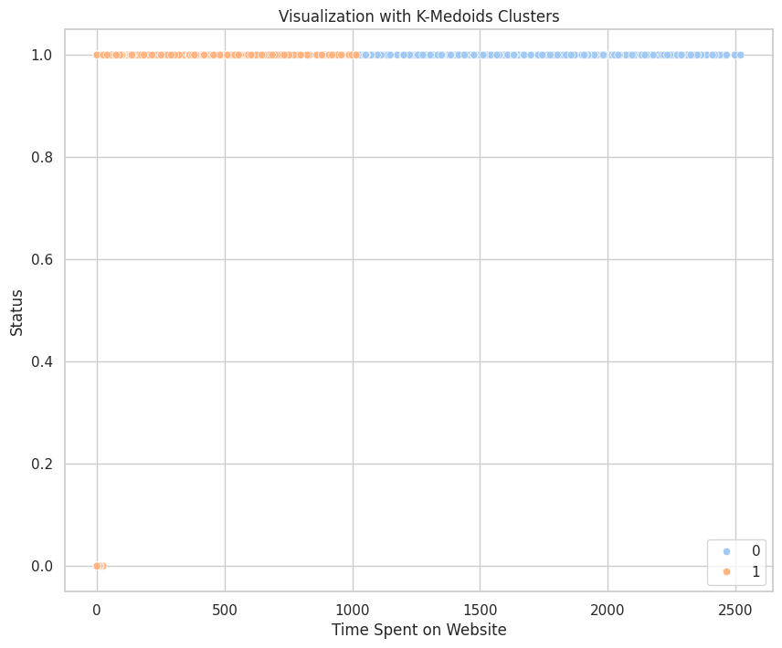

```python
# Specify the number of clusters
num_clusters = 2


# Select numerical columns for clustering
numerical_columns = X_fold_val

# Initialize K-Medoids model
kmedoids = KMedoids(n_clusters=num_clusters, random_state=42)

# Fit K-Medoids model
cluster_assignments = kmedoids.fit_predict(numerical_columns)

# Visualize clustering results
plt.figure(figsize=(10, 8))
sns.scatterplot(x=numerical_columns.iloc[:, 2], y=y_pred_val_binary.ravel(), hue=cluster_assignments, legend='full')

# Set labels and title
plt.xlabel('Time Spent on Website')
plt.ylabel('Status')
plt.title('Visualization with K-Medoids Clusters')

# Show the plot
plt.show()
```

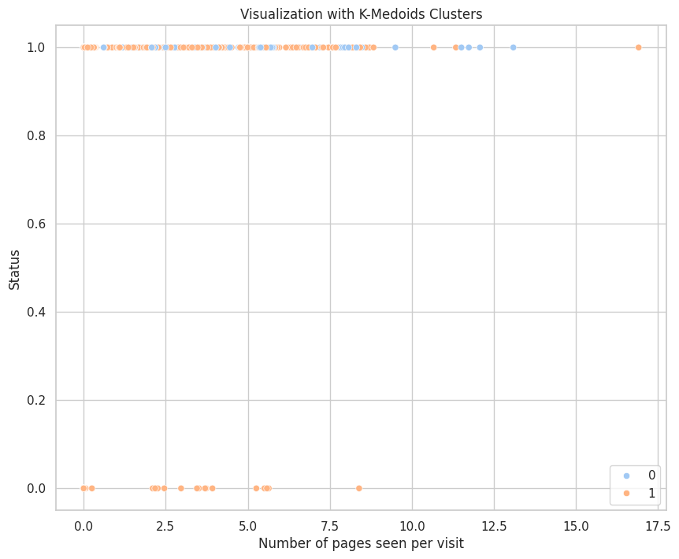

```python
# Specify the number of clusters
num_clusters = 2


# Select numerical columns for clustering
numerical_columns = X_fold_val

# Initialize K-Medoids model
kmedoids = KMedoids(n_clusters=num_clusters, random_state=42)

# Fit K-Medoids model
cluster_assignments = kmedoids.fit_predict(numerical_columns)

# Visualize clustering results
plt.figure(figsize=(10, 8))
sns.scatterplot(x=numerical_columns.iloc[:, 3], y=y_pred_val_binary.ravel(), hue=cluster_assignments, legend='full')

# Set labels and title
plt.xlabel('Number of pages seen per visit')
plt.ylabel('Status')
plt.title('Visualization with K-Medoids Clusters')

# Show the plot
plt.show()
```

The number of pages seen per visit discriminate poorly amongst lead. Occupation and other categorical variables do not discriminate either.

We now look at the XGBoost predictions to portray converted leads.

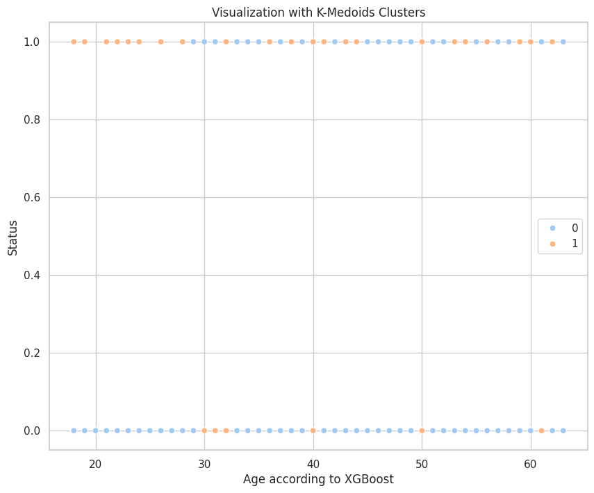

```python
# Specify the number of clusters
num_clusters = 2


# Select numerical columns for clustering
numerical_columns = X_test

# Initialize K-Medoids model
kmedoids = KMedoids(n_clusters=num_clusters, random_state=42)

# Fit K-Medoids model
cluster_assignments = kmedoids.fit_predict(numerical_columns)

# Visualize clustering results
plt.figure(figsize=(10, 8))
sns.scatterplot(x=numerical_columns.iloc[:, 0], y=xgb.predict(X_test).ravel(), hue=cluster_assignments, legend='full')

# Set labels and title
plt.xlabel('Age according to XGBoost')
plt.ylabel('Status')
plt.title('Visualization with K-Medoids Clusters')

# Show the plot
plt.show()
```

We observe a finer pattern in age but the relationship is still non linear.

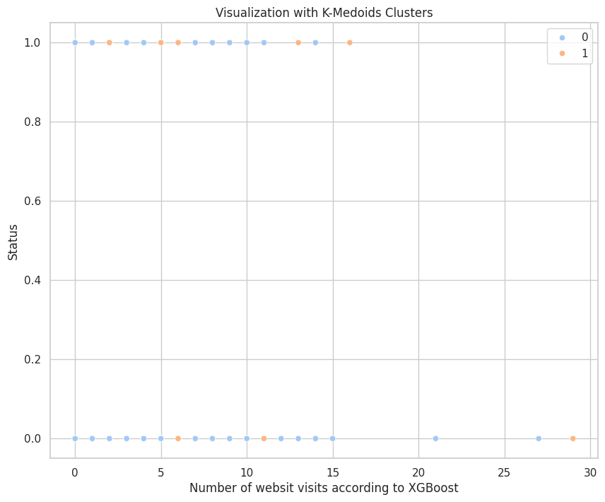

```python
# Specify the number of clusters
num_clusters = 2


# Select numerical columns for clustering
numerical_columns = X_test

# Initialize K-Medoids model
kmedoids = KMedoids(n_clusters=num_clusters, random_state=42)

# Fit K-Medoids model
cluster_assignments = kmedoids.fit_predict(numerical_columns)

# Visualize clustering results
plt.figure(figsize=(10, 8))
sns.scatterplot(x=numerical_columns.iloc[:, 1], y=xgb.predict(X_test).ravel(), hue=cluster_assignments, legend='full')

# Set labels and title
plt.xlabel('Number of websit visits according to XGBoost')
plt.ylabel('Status')
plt.title('Visualization with K-Medoids Clusters')

# Show the plot
plt.show()
```

# Summary

1. Conversion likelihood is highly dependant on the company s website and application efficiency, more than on ad exposure of references.
2. Age matters although we can suspect networks dynamics within individuals of the same age and not individual across age group.
3. Occupation is not a good predictor of conversion.
4. Completeness of profile does influence conversion positively although it is a by product of root predictors i.e., time spent on the website and number of website visits

# Recommendations

Improve the mobile app and the website through:

- Better Customer Onboarding. Provide only the essential information at the beginning of the customer experience.
- Ergonomic and Simple Login Screen. Provide simple registration, allowing users to login from external accounts such as Facebook or Google. Only ask users for information that is needed.
- Simple Menus and Navigation
- Reduce Search Effort
- Improve interface design

Those actionable insights will help the company attract more leads under 30 years old and its conversion rate in this demographic specifically through network effects (mobile app leverage), and its overall market coverage (website leverage).